# Patient Churn Prediction in Healthcare

### Introduction

In healthcare, patient churn, or attrition, significantly impacts revenue and continuity of care. For patients requiring chronic and regular care, discontinuity can lead to adverse health outcomes. The "Patient Churn Prediction in Healthcare" project seeks to predict patient churn to assist healthcare providers in understanding patient tendencies using demographic, clinical, and behavioral data. Addressing patient churn is critical for sustaining financial health and retaining patients, allowing providers to develop strategies for sustained engagement.

### Objectives and Dataset

The objectives in the document align closely with the goals of this project:

1. **Predicting Churn Likelihood:** The project utilizes models that analyze demographics, clinical history, and visit frequency data to predict churn probability.
2. **Identifying Patterns:** The approach emphasizes recognizing key churn indicators, which are valuable in helping healthcare providers identify high-risk profiles.
3. **Service Profitability:** Retaining patients at risk of churning prevents revenue loss and ensures better continuity of care.

The dataset incorporates key variables such as demographic information, clinical history, and visit frequency, which are foundational in predicting patient churn. These input parameters directly address patient profiles that are at higher risk of discontinuing care, making the model relevant and actionable for healthcare providers.

## 2. Loading Libraries and Data

```python
import pandas as pd
import numpy as np
import missingno as msno
import matplotlib.pyplot as plt
import seaborn as sns
import plotly.express as px
import plotly.graph_objects as go
from plotly.subplots import make_subplots
import warnings
warnings.filterwarnings('ignore')
```

```python
from sklearn.preprocessing import StandardScaler
from sklearn.preprocessing import LabelEncoder
from sklearn.tree import DecisionTreeClassifier
from sklearn.ensemble import RandomForestClassifier
from sklearn.naive_bayes import GaussianNB
from sklearn.neighbors import KNeighborsClassifier
from sklearn.svm import SVC
from sklearn.neural_network import MLPClassifier
from sklearn.ensemble import AdaBoostClassifier
from sklearn.ensemble import GradientBoostingClassifier
from sklearn.ensemble import ExtraTreesClassifier
from sklearn.linear_model import LogisticRegression
from sklearn.model_selection import train_test_split
from sklearn.metrics import accuracy_score
from xgboost import XGBClassifier
from catboost import CatBoostClassifier
from sklearn import metrics
from sklearn.metrics import roc_curve
from sklearn.metrics import recall_score, confusion_matrix, precision_score, f1_score, accuracy_score, classification_report
```

```python
#loading data
df = pd.read_csv("D:/projects/patient_churn.csv")
```

## 3. Undertanding the Data

Each row represents a patient, each column contains patients’s attributes described on the column Metadata.

```python
df.head()
```

|  | patientID | gender | AgeGroup | PrimaryCareGiver | Dependents | MonthsWithClinic | OnlineServices | VisitFrequency | ElectronicRecords | PaymentMethod | TreatmentFee | TotalTreatmentCost | Churn |
| --- | --- | --- | --- | --- | --- | --- | --- | --- | --- | --- | --- | --- | --- |
| 0 | 7590-VHVEG | Female | 0 | Yes | No | 1 | No | Month-to-month | Yes | Electronic check | 29.85 | 29.85 | No |
| 1 | 5575-GNVDE | Male | 0 | No | No | 34 | Yes | One year | No | Mailed check | 56.95 | 1889.5 | No |
| 2 | 3668-QPYBK | Male | 0 | No | No | 2 | Yes | Month-to-month | Yes | Mailed check | 53.85 | 108.15 | Yes |
| 3 | 7795-CFOCW | Male | 0 | No | No | 45 | Yes | One year | No | Bank transfer (automatic) | 42.30 | 1840.75 | No |
| 4 | 9237-HQITU | Female | 0 | No | No | 2 | No | Month-to-month | Yes | Electronic check | 70.70 | 151.65 | Yes |

```python
df.shape
```

```
(7043, 13)
```

```python
df.info()
```

```
<class 'pandas.core.frame.DataFrame'>
RangeIndex: 7043 entries, 0 to 7042
Data columns (total 13 columns):
 #   Column              Non-Null Count  Dtype
---  ------              --------------  -----
 0   patientID           7043 non-null   object
 1   gender              7043 non-null   object
 2   AgeGroup            7043 non-null   int64
 3   PrimaryCareGiver    7043 non-null   object
 4   Dependents          7043 non-null   object
 5   MonthsWithClinic    7043 non-null   int64
 6   OnlineServices      7043 non-null   object
 7   VisitFrequency      7043 non-null   object
 8   ElectronicRecords   7043 non-null   object
 9   PaymentMethod       7043 non-null   object
 10  TreatmentFee        7043 non-null   float64
 11  TotalTreatmentCost  7043 non-null   object
 12  Churn               7043 non-null   object
dtypes: float64(1), int64(2), object(10)
memory usage: 715.4+ KB
```

```python
df.columns.values
```

```
array(['patientID', 'gender', 'AgeGroup', 'PrimaryCareGiver',
       'Dependents', 'MonthsWithClinic', 'OnlineServices',
       'VisitFrequency', 'ElectronicRecords', 'PaymentMethod',
       'TreatmentFee', 'TotalTreatmentCost', 'Churn'], dtype=object)
```

```python
df.dtypes
```

```
patientID              object
gender                 object
AgeGroup                int64
PrimaryCareGiver       object
Dependents             object
MonthsWithClinic        int64
OnlineServices         object
VisitFrequency         object
ElectronicRecords      object
PaymentMethod          object
TreatmentFee          float64
TotalTreatmentCost     object
Churn                  object
dtype: object
```

- The target the we will use to guide the exploration is **Churn**

## 4. Visualize Missing Values

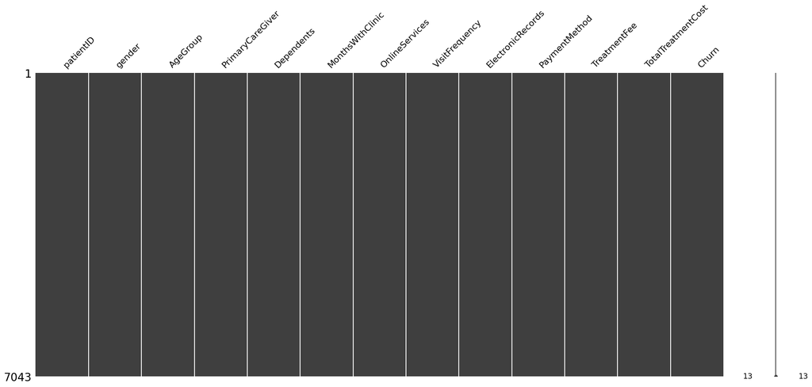

```python
# Visualize missing values as a matrix
msno.matrix(df);
```

> Using this matrix we can very quickly find the pattern of missingness in the dataset.
- From the above visualisation we can observe that it has no peculiar pattern that stands out. In fact there is no missing data.

## 5. Data Manipulation

```python
df = df.drop(['patientID'], axis = 1)
df.head()
```

|  | gender | AgeGroup | PrimaryCareGiver | Dependents | MonthsWithClinic | OnlineServices | VisitFrequency | ElectronicRecords | PaymentMethod | TreatmentFee | TotalTreatmentCost | Churn |
| --- | --- | --- | --- | --- | --- | --- | --- | --- | --- | --- | --- | --- |
| 0 | Female | 0 | Yes | No | 1 | No | Month-to-month | Yes | Electronic check | 29.85 | 29.85 | No |
| 1 | Male | 0 | No | No | 34 | Yes | One year | No | Mailed check | 56.95 | 1889.5 | No |
| 2 | Male | 0 | No | No | 2 | Yes | Month-to-month | Yes | Mailed check | 53.85 | 108.15 | Yes |
| 3 | Male | 0 | No | No | 45 | Yes | One year | No | Bank transfer (automatic) | 42.30 | 1840.75 | No |
| 4 | Female | 0 | No | No | 2 | No | Month-to-month | Yes | Electronic check | 70.70 | 151.65 | Yes |

- On deep analysis, we can find some indirect missingness in our data (which can be in form of blankspaces). Let's see that!

```python
df['TotalTreatmentCost'] = pd.to_numeric(df.TotalTreatmentCost, errors='coerce')
df.isnull().sum()
```

```
gender                 0
AgeGroup               0
PrimaryCareGiver       0
Dependents             0
MonthsWithClinic       0
OnlineServices         0
VisitFrequency         0
ElectronicRecords      0
PaymentMethod          0
TreatmentFee           0
TotalTreatmentCost    11
Churn                  0
dtype: int64
```

- Here we see that the TotalTreatmentCost has 11 missing values. Let's check this data.

```python
df[np.isnan(df['TotalTreatmentCost'])]
```

|  | gender | AgeGroup | PrimaryCareGiver | Dependents | MonthsWithClinic | OnlineServices | VisitFrequency | ElectronicRecords | PaymentMethod | TreatmentFee | TotalTreatmentCost | Churn |
| --- | --- | --- | --- | --- | --- | --- | --- | --- | --- | --- | --- | --- |
| 488 | Female | 0 | Yes | Yes | 0 | Yes | Two year | Yes | Bank transfer (automatic) | 52.55 | NaN | No |
| 753 | Male | 0 | No | Yes | 0 | No internet service | Two year | No | Mailed check | 20.25 | NaN | No |
| 936 | Female | 0 | Yes | Yes | 0 | Yes | Two year | No | Mailed check | 80.85 | NaN | No |
| 1082 | Male | 0 | Yes | Yes | 0 | No internet service | Two year | No | Mailed check | 25.75 | NaN | No |
| 1340 | Female | 0 | Yes | Yes | 0 | Yes | Two year | No | Credit card (automatic) | 56.05 | NaN | No |
| 3331 | Male | 0 | Yes | Yes | 0 | No internet service | Two year | No | Mailed check | 19.85 | NaN | No |
| 3826 | Male | 0 | Yes | Yes | 0 | No internet service | Two year | No | Mailed check | 25.35 | NaN | No |
| 4380 | Female | 0 | Yes | Yes | 0 | No internet service | Two year | No | Mailed check | 20.00 | NaN | No |
| 5218 | Male | 0 | Yes | Yes | 0 | No internet service | One year | Yes | Mailed check | 19.70 | NaN | No |
| 6670 | Female | 0 | Yes | Yes | 0 | No | Two year | No | Mailed check | 73.35 | NaN | No |
| 6754 | Male | 0 | No | Yes | 0 | Yes | Two year | Yes | Bank transfer (automatic) | 61.90 | NaN | No |

- It can also be noted that the MonthsWithClinic column is 0 for these entries even though the TreatmentFee column is not empty.

Let's see if there are any other 0 values in the MonthsWithClinic column.

```python
df[df['MonthsWithClinic'] == 0].index
```

```
Index([488, 753, 936, 1082, 1340, 3331, 3826, 4380, 5218, 6670, 6754], dtype='int64')
```

- There are no additional missing values in the MonthsWithClinic column.

Let's delete the rows with missing values in TMonthsWithClinic columns since there are only 11 rows and deleting them will not affect the data.

```python
df.drop(labels=df[df['MonthsWithClinic'] == 0].index, axis=0, inplace=True)
df[df['MonthsWithClinic'] == 0].index
```

```
Index([], dtype='int64')
```

> To solve the problem of missing values in TotalTreatmentFee column, I decided to fill it with the mean of TotalTreatmentFee values.

```python
df.fillna(df["TotalTreatmentCost"].mean())
```

|  | gender | AgeGroup | PrimaryCareGiver | Dependents | MonthsWithClinic | OnlineServices | VisitFrequency | ElectronicRecords | PaymentMethod | TreatmentFee | TotalTreatmentCost | Churn |
| --- | --- | --- | --- | --- | --- | --- | --- | --- | --- | --- | --- | --- |
| 0 | Female | 0 | Yes | No | 1 | No | Month-to-month | Yes | Electronic check | 29.85 | 29.85 | No |
| 1 | Male | 0 | No | No | 34 | Yes | One year | No | Mailed check | 56.95 | 1889.50 | No |
| 2 | Male | 0 | No | No | 2 | Yes | Month-to-month | Yes | Mailed check | 53.85 | 108.15 | Yes |
| 3 | Male | 0 | No | No | 45 | Yes | One year | No | Bank transfer (automatic) | 42.30 | 1840.75 | No |
| 4 | Female | 0 | No | No | 2 | No | Month-to-month | Yes | Electronic check | 70.70 | 151.65 | Yes |
| ... | ... | ... | ... | ... | ... | ... | ... | ... | ... | ... | ... | ... |
| 7038 | Male | 0 | Yes | Yes | 24 | Yes | One year | Yes | Mailed check | 84.80 | 1990.50 | No |
| 7039 | Female | 0 | Yes | Yes | 72 | No | One year | Yes | Credit card (automatic) | 103.20 | 7362.90 | No |
| 7040 | Female | 0 | Yes | Yes | 11 | Yes | Month-to-month | Yes | Electronic check | 29.60 | 346.45 | No |
| 7041 | Male | 1 | Yes | No | 4 | No | Month-to-month | Yes | Mailed check | 74.40 | 306.60 | Yes |
| 7042 | Male | 0 | No | No | 66 | Yes | Two year | Yes | Bank transfer (automatic) | 105.65 | 6844.50 | No |

7032 rows × 12 columns

```python
df.isnull().sum()
```

```
gender                0
AgeGroup              0
PrimaryCareGiver      0
Dependents            0
MonthsWithClinic      0
OnlineServices        0
VisitFrequency        0
ElectronicRecords     0
PaymentMethod         0
TreatmentFee          0
TotalTreatmentCost    0
Churn                 0
dtype: int64
```

```python
df["AgeGroup"]= df["AgeGroup"].map({0: "No", 1: "Yes"})
df.head()
```

|  | gender | AgeGroup | PrimaryCareGiver | Dependents | MonthsWithClinic | OnlineServices | VisitFrequency | ElectronicRecords | PaymentMethod | TreatmentFee | TotalTreatmentCost | Churn |
| --- | --- | --- | --- | --- | --- | --- | --- | --- | --- | --- | --- | --- |
| 0 | Female | No | Yes | No | 1 | No | Month-to-month | Yes | Electronic check | 29.85 | 29.85 | No |
| 1 | Male | No | No | No | 34 | Yes | One year | No | Mailed check | 56.95 | 1889.50 | No |
| 2 | Male | No | No | No | 2 | Yes | Month-to-month | Yes | Mailed check | 53.85 | 108.15 | Yes |
| 3 | Male | No | No | No | 45 | Yes | One year | No | Bank transfer (automatic) | 42.30 | 1840.75 | No |
| 4 | Female | No | No | No | 2 | No | Month-to-month | Yes | Electronic check | 70.70 | 151.65 | Yes |

```python
numerical_cols = ['MonthsWithClinic', 'TreatmentFee', 'TotalTreatmentCost']
df[numerical_cols].describe()
```

|  | MonthsWithClinic | TreatmentFee | TotalTreatmentCost |
| --- | --- | --- | --- |
| count | 7032.000000 | 7032.000000 | 7032.000000 |
| mean | 32.421786 | 64.798208 | 2283.300441 |
| std | 24.545260 | 30.085974 | 2266.771362 |
| min | 1.000000 | 18.250000 | 18.800000 |
| 25% | 9.000000 | 35.587500 | 401.450000 |
| 50% | 29.000000 | 70.350000 | 1397.475000 |
| 75% | 55.000000 | 89.862500 | 3794.737500 |
| max | 72.000000 | 118.750000 | 8684.800000 |

## 6. Data Visualization

```python
g_labels = ['Male', 'Female']
c_labels = ['No', 'Yes']
# Create subplots: use 'domain' type for Pie subplot
fig = make_subplots(rows=1, cols=2, specs=[[{'type':'domain'}, {'type':'domain'}]])
fig.add_trace(go.Pie(labels=g_labels, values=df['gender'].value_counts(), name="Gender"),
              1, 1)
fig.add_trace(go.Pie(labels=c_labels, values=df['Churn'].value_counts(), name="Churn"),
              1, 2)

# Use `hole` to create a donut-like pie chart
fig.update_traces(hole=.4, hoverinfo="label+percent+name", textfont_size=16)

fig.update_layout(
    title_text="Gender and Churn Distributions",
    # Add annotations in the center of the donut pies.
    annotations=[dict(text='Gender', x=0.16, y=0.5, font_size=20, showarrow=False),
                 dict(text='Churn', x=0.84, y=0.5, font_size=20, showarrow=False)])
fig.show()
```

- 26.6 % of patients switched to another facility.
- Patients are 49.5 % female and 50.5 % male.

```python
df["Churn"][df["Churn"]=="No"].groupby(by=df["gender"]).count()
```

```
gender
Female    2544
Male      2619
Name: Churn, dtype: int64
```

```python
df["Churn"][df["Churn"]=="Yes"].groupby(by=df["gender"]).count()
```

```
gender
Female    939
Male      930
Name: Churn, dtype: int64
```

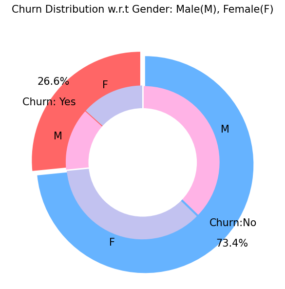

```python
plt.figure(figsize=(6, 6))
labels =["Churn: Yes","Churn:No"]
values = [1869,5163]
labels_gender = ["F","M","F","M"]
sizes_gender = [939,930 , 2544,2619]
colors = ['#ff6666', '#66b3ff']
colors_gender = ['#c2c2f0','#ffb3e6', '#c2c2f0','#ffb3e6']
explode = (0.3,0.3)
explode_gender = (0.1,0.1,0.1,0.1)
textprops = {"fontsize":15}
#Plot
plt.pie(values, labels=labels,autopct='%1.1f%%',pctdistance=1.08, labeldistance=0.8,colors=colors, startangle=90,frame=True, explode=explode,radius=10, textprops =textprops, counterclock = True, )
plt.pie(sizes_gender,labels=labels_gender,colors=colors_gender,startangle=90, explode=explode_gender,radius=7, textprops =textprops, counterclock = True, )
#Draw circle
centre_circle = plt.Circle((0,0),5,color='black', fc='white',linewidth=0)
fig = plt.gcf()
fig.gca().add_artist(centre_circle)

plt.title('Churn Distribution w.r.t Gender: Male(M), Female(F)', fontsize=15, y=1.1)

# show plot

plt.axis('equal')
plt.tight_layout()
plt.show()
```

```python
fig = px.histogram(df, x="Churn", color="VisitFrequency", barmode="group", title="<b>Patient Visit Distribution<b>")
fig.update_layout(width=700, height=500, bargap=0.1)
fig.show()
```

```python
labels = df['PaymentMethod'].unique()
values = df['PaymentMethod'].value_counts()

fig = go.Figure(data=[go.Pie(labels=labels, values=values, hole=.3)])
fig.update_layout(title_text="<b>Payment Method Distribution</b>")
fig.show()
```

```python
fig = px.histogram(df, x="Churn", color="PaymentMethod", title="<b>Customer Payment Method distribution w.r.t. Churn</b>")
fig.update_layout(width=700, height=500, bargap=0.1)
fig.show()
```

```python
color_map = {"Yes": "#FF97FF", "No": "#AB63FA"}
fig = px.histogram(df, x="Churn", color="Dependents", barmode="group", title="<b>Dependents distribution</b>", color_discrete_map=color_map)
fig.update_layout(width=700, height=500, bargap=0.1)
fig.show()
```

```python
color_map = {"Yes": '#FFA15A', "No": '#00CC96'}
fig = px.histogram(df, x="Churn", color="PrimaryCareGiver", barmode="group", title="<b>Chrun distribution w.r.t. Primary CareGivers</b>", color_discrete_map=color_map)
fig.update_layout(width=700, height=500, bargap=0.1)
fig.show()
```

```python
color_map = {"Yes": '#00CC96', "No": '#B6E880'}
fig = px.histogram(df, x="Churn", color="AgeGroup", title="<b>Chrun distribution w.r.t. AgeGroup</b>", color_discrete_map=color_map)
fig.update_layout(width=700, height=500, bargap=0.1)
fig.show()
```

```python
color_map = {"Yes": "#FF97FF", "No": "#AB63FA"}
fig = px.histogram(df, x="Churn", color="OnlineServices", barmode="group", title="<b>Churn w.r.t Online Services</b>", color_discrete_map=color_map)
fig.update_layout(width=700, height=500, bargap=0.1)
fig.show()
```

```python
color_map = {"Yes": '#FFA15A', "No": '#00CC96'}
fig = px.histogram(df, x="Churn", color="ElectronicRecords",  title="<b>Chrun distribution w.r.t. Electronic Records</b>", color_discrete_map=color_map)
fig.update_layout(width=700, height=500, bargap=0.1)
fig.show()
```

- Patients with Electronic Records are most likely to churn.

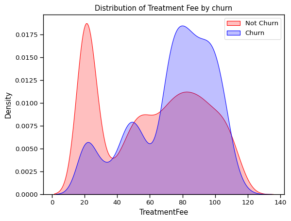

```python
sns.set_context("paper",font_scale=1.1)
ax = sns.kdeplot(df.TreatmentFee[(df["Churn"] == 'No') ],
                color="Red", shade = True);
ax = sns.kdeplot(df.TreatmentFee[(df["Churn"] == 'Yes') ],
                ax =ax, color="Blue", shade= True);
ax.legend(["Not Churn","Churn"],loc='upper right');
ax.set_ylabel('Density');
ax.set_xlabel('TreatmentFee');
ax.set_title('Distribution of Treatment Fee by churn');
```

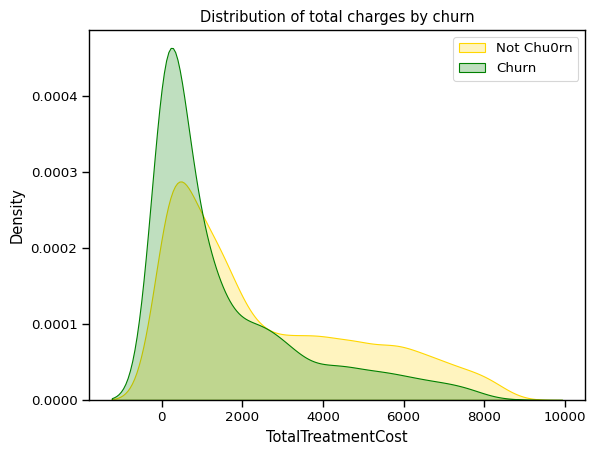

```python
ax = sns.kdeplot(df.TotalTreatmentCost[(df["Churn"] == 'No') ],
                color="Gold", shade = True);
ax = sns.kdeplot(df.TotalTreatmentCost[(df["Churn"] == 'Yes') ],
                ax =ax, color="Green", shade= True);
ax.legend(["Not Chu0rn","Churn"],loc='upper right');
ax.set_ylabel('Density');
ax.set_xlabel('TotalTreatmentCost');
ax.set_title('Distribution of total charges by churn');
```

```python
fig = px.box(df, x='Churn', y = 'MonthsWithClinic')

# Update yaxis properties
fig.update_yaxes(title_text='Tenure (Months)', row=1, col=1)
# Update xaxis properties
fig.update_xaxes(title_text='Churn', row=1, col=1)

# Update size and title
fig.update_layout(autosize=True, width=750, height=600,
    title_font=dict(size=25, family='Courier'),
    title='<b>Tenure vs Churn</b>',
)

fig.show()
```

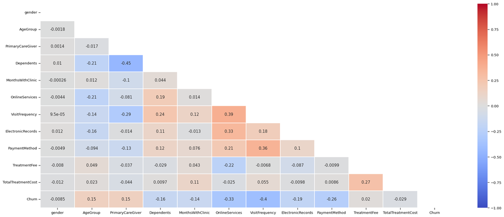

```python
plt.figure(figsize=(25, 10))

corr = df.apply(lambda x: pd.factorize(x)[0]).corr()

mask = np.triu(np.ones_like(corr, dtype=bool))

ax = sns.heatmap(corr, mask=mask, xticklabels=corr.columns, yticklabels=corr.columns, annot=True, linewidths=.2, cmap='coolwarm', vmin=-1, vmax=1)
```

## 7. Data Preprocessing

#### **Splitting the data into train and test sets**

```python
def object_to_int(dataframe_series):
    if dataframe_series.dtype=='object':
        dataframe_series = LabelEncoder().fit_transform(dataframe_series)
    return dataframe_series
```

```python
df = df.apply(lambda x: object_to_int(x))
df.head()
```

|  | gender | AgeGroup | PrimaryCareGiver | Dependents | MonthsWithClinic | OnlineServices | VisitFrequency | ElectronicRecords | PaymentMethod | TreatmentFee | TotalTreatmentCost | Churn |
| --- | --- | --- | --- | --- | --- | --- | --- | --- | --- | --- | --- | --- |
| 0 | 0 | 0 | 1 | 0 | 1 | 0 | 0 | 1 | 2 | 29.85 | 29.85 | 0 |
| 1 | 1 | 0 | 0 | 0 | 34 | 2 | 1 | 0 | 3 | 56.95 | 1889.50 | 0 |
| 2 | 1 | 0 | 0 | 0 | 2 | 2 | 0 | 1 | 3 | 53.85 | 108.15 | 1 |
| 3 | 1 | 0 | 0 | 0 | 45 | 2 | 1 | 0 | 0 | 42.30 | 1840.75 | 0 |
| 4 | 0 | 0 | 0 | 0 | 2 | 0 | 0 | 1 | 2 | 70.70 | 151.65 | 1 |

```python
plt.figure(figsize=(14,7))
df.corr()['Churn'].sort_values(ascending = False)
```

```
Churn                 1.000000
TreatmentFee          0.192858
ElectronicRecords     0.191454
AgeGroup              0.150541
PaymentMethod         0.107852
gender               -0.008545
PrimaryCareGiver     -0.149982
Dependents           -0.163128
TotalTreatmentCost   -0.199484
OnlineServices       -0.289050
MonthsWithClinic     -0.354049
VisitFrequency       -0.396150
Name: Churn, dtype: float64
```

```python
X = df.drop(columns = ['Churn'])
y = df['Churn'].values
```

```python
X_train, X_test, y_train, y_test = train_test_split(X,y,test_size = 0.30, random_state = 40, stratify=y)
```

```python
def distplot(feature, frame, color='r'):
    plt.figure(figsize=(8,3))
    plt.title("Distribution for {}".format(feature))
    ax = sns.distplot(frame[feature], color= color)
```

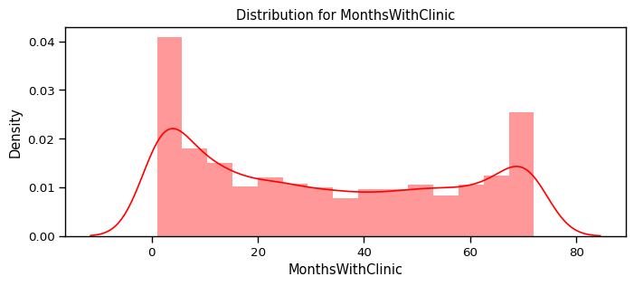

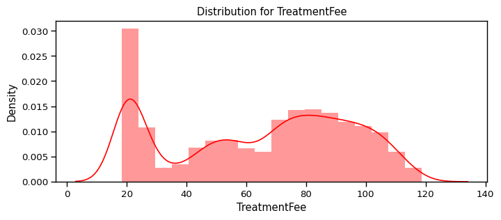

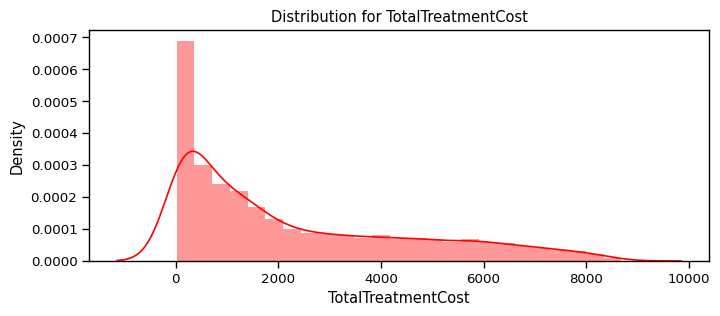

```python
num_cols = ["MonthsWithClinic", 'TreatmentFee', 'TotalTreatmentCost']
for feat in num_cols: distplot(feat, df)
```

Since the numerical features are distributed over different value ranges, I will use standard scalar to scale them down to the same range.

#### **Standardizing numeric attributes**

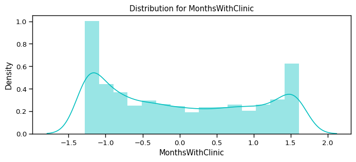

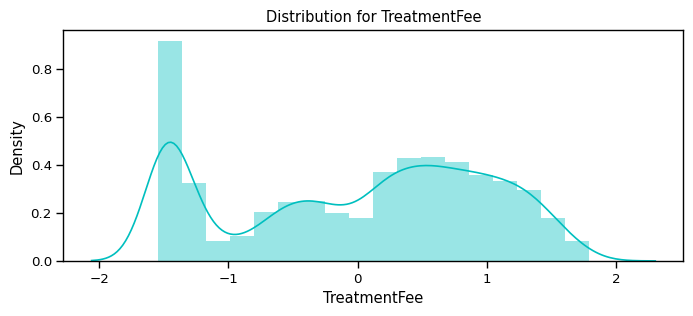

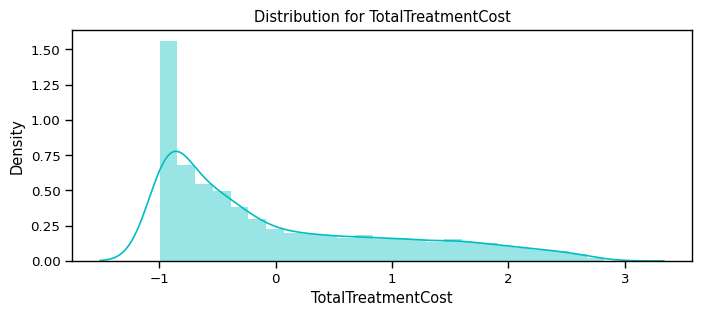

```python
df_std = pd.DataFrame(StandardScaler().fit_transform(df[num_cols].astype('float64')),
                       columns=num_cols)
for feat in numerical_cols: distplot(feat, df_std, color='c')
```

```python
# Divide the columns into 3 categories, one ofor standardisation, one for label encoding and one for one hot encoding

cat_cols_ohe =['PaymentMethod', 'VisitFrequency'] # those that need one-hot encoding
cat_cols_le = list(set(X_train.columns)- set(num_cols) - set(cat_cols_ohe)) #those that need label encoding
```

```python
scaler= StandardScaler()

X_train[num_cols] = scaler.fit_transform(X_train[num_cols])
X_test[num_cols] = scaler.transform(X_test[num_cols])
```

# 8. Machine Learning Model Evaluations and Predictions

#### **KNN**

```python
knn_model = KNeighborsClassifier(n_neighbors = 11)
knn_model.fit(X_train,y_train)
predicted_y = knn_model.predict(X_test)
accuracy_knn = knn_model.score(X_test,y_test)
print("KNN accuracy:",accuracy_knn)
```

```
KNN accuracy: 0.7753554502369668
```

```python
print(classification_report(y_test, predicted_y))
```

```
              precision    recall  f1-score   support

           0       0.83      0.88      0.85      1549
           1       0.59      0.49      0.54       561

    accuracy                           0.78      2110
   macro avg       0.71      0.68      0.69      2110
weighted avg       0.76      0.78      0.77      2110
```

#### **SVC**

```python
svc_model = SVC(random_state = 1)
svc_model.fit(X_train,y_train)
predict_y = svc_model.predict(X_test)
accuracy_svc = svc_model.score(X_test,y_test)
print("SVM accuracy is :",accuracy_svc)
```

```
SVM accuracy is : 0.8004739336492891
```

```python
print(classification_report(y_test, predict_y))
```

```
              precision    recall  f1-score   support

           0       0.83      0.92      0.87      1549
           1       0.69      0.46      0.55       561

    accuracy                           0.80      2110
   macro avg       0.76      0.69      0.71      2110
weighted avg       0.79      0.80      0.79      2110
```

#### **Random Forest**

```python
from sklearn.ensemble import RandomForestClassifier
from sklearn import metrics

model_rf = RandomForestClassifier(
    n_estimators=500,
    oob_score=True,
    n_jobs=-1,
    random_state=50,
    max_features="sqrt",  # Changed from "auto" to "sqrt"
    max_leaf_nodes=30
)

model_rf.fit(X_train, y_train)

# Make predictions
prediction_test = model_rf.predict(X_test)
print(metrics.accuracy_score(y_test, prediction_test))
```

```
0.809478672985782
```

```python
print(classification_report(y_test, prediction_test))
```

```
              precision    recall  f1-score   support

           0       0.84      0.92      0.88      1549
           1       0.70      0.50      0.58       561

    accuracy                           0.81      2110
   macro avg       0.77      0.71      0.73      2110
weighted avg       0.80      0.81      0.80      2110
```

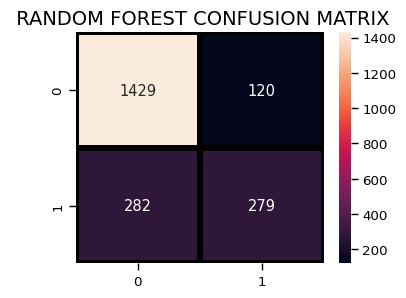

```python
plt.figure(figsize=(4,3))
sns.heatmap(confusion_matrix(y_test, prediction_test),
                annot=True,fmt = "d",linecolor="k",linewidths=3)

plt.title(" RANDOM FOREST CONFUSION MATRIX",fontsize=14)
plt.show()
```

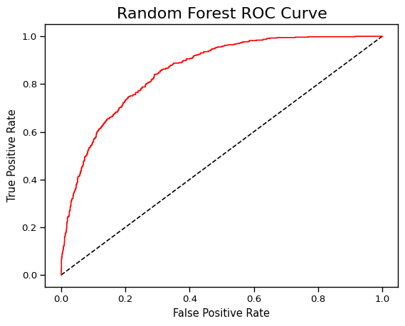

```python
y_rfpred_prob = model_rf.predict_proba(X_test)[:,1]
fpr_rf, tpr_rf, thresholds = roc_curve(y_test, y_rfpred_prob)
plt.plot([0, 1], [0, 1], 'k--' )
plt.plot(fpr_rf, tpr_rf, label='Random Forest',color = "r")
plt.xlabel('False Positive Rate')
plt.ylabel('True Positive Rate')
plt.title('Random Forest ROC Curve',fontsize=16)
plt.show();
```

#### **Logistic Regression**

```python
lr_model = LogisticRegression()
lr_model.fit(X_train,y_train)
accuracy_lr = lr_model.score(X_test,y_test)
print("Logistic Regression accuracy is :",accuracy_lr)
```

```
Logistic Regression accuracy is : 0.8023696682464455
```

```python
lr_pred= lr_model.predict(X_test)
report = classification_report(y_test,lr_pred)
print(report)
```

```
              precision    recall  f1-score   support

           0       0.84      0.90      0.87      1549
           1       0.66      0.54      0.59       561

    accuracy                           0.80      2110
   macro avg       0.75      0.72      0.73      2110
weighted avg       0.79      0.80      0.80      2110
```

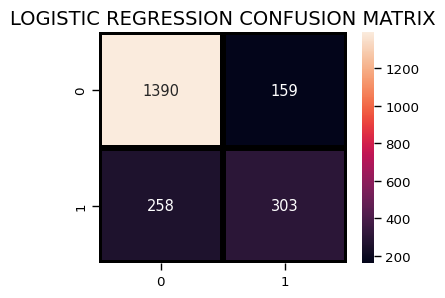

```python
plt.figure(figsize=(4,3))
sns.heatmap(confusion_matrix(y_test, lr_pred),
                annot=True,fmt = "d",linecolor="k",linewidths=3)

plt.title("LOGISTIC REGRESSION CONFUSION MATRIX",fontsize=14)
plt.show()
```

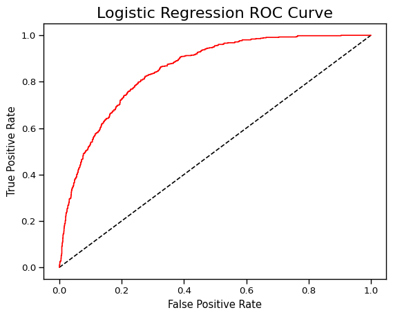

```python
y_pred_prob = lr_model.predict_proba(X_test)[:,1]
fpr, tpr, thresholds = roc_curve(y_test, y_pred_prob)
plt.plot([0, 1], [0, 1], 'k--' )
plt.plot(fpr, tpr, label='Logistic Regression',color = "r")
plt.xlabel('False Positive Rate')
plt.ylabel('True Positive Rate')
plt.title('Logistic Regression ROC Curve',fontsize=16)
plt.show();
```

#### **Decision Tree Classifier**

```python
dt_model = DecisionTreeClassifier()
dt_model.fit(X_train,y_train)
predictdt_y = dt_model.predict(X_test)
accuracy_dt = dt_model.score(X_test,y_test)
print("Decision Tree accuracy is :",accuracy_dt)
```

```
Decision Tree accuracy is : 0.718957345971564
```

Decision tree gives very low score.

```python
print(classification_report(y_test, predictdt_y))
```

```
              precision    recall  f1-score   support

           0       0.82      0.79      0.80      1549
           1       0.47      0.52      0.50       561

    accuracy                           0.72      2110
   macro avg       0.65      0.66      0.65      2110
weighted avg       0.73      0.72      0.72      2110
```

#### **AdaBoost Classifier**

```python
a_model = AdaBoostClassifier()
a_model.fit(X_train,y_train)
a_preds = a_model.predict(X_test)
print("AdaBoost Classifier accuracy")
metrics.accuracy_score(y_test, a_preds)
```

```
AdaBoost Classifier accuracy
```

```
0.8023696682464455
```

```python
print(classification_report(y_test, a_preds))
```

```
              precision    recall  f1-score   support

           0       0.84      0.90      0.87      1549
           1       0.66      0.53      0.59       561

    accuracy                           0.80      2110
   macro avg       0.75      0.71      0.73      2110
weighted avg       0.79      0.80      0.79      2110
```

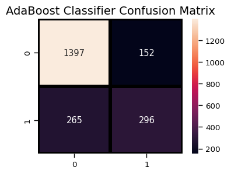

```python
plt.figure(figsize=(4,3))
sns.heatmap(confusion_matrix(y_test, a_preds),
                annot=True,fmt = "d",linecolor="k",linewidths=3)

plt.title("AdaBoost Classifier Confusion Matrix",fontsize=14)
plt.show()
```

#### **Gradient Boosting Classifier**

```python
gb = GradientBoostingClassifier()
gb.fit(X_train, y_train)
gb_pred = gb.predict(X_test)
print("Gradient Boosting Classifier", accuracy_score(y_test, gb_pred))
```

```
Gradient Boosting Classifier 0.8080568720379147
```

```python
print(classification_report(y_test, gb_pred))
```

```
              precision    recall  f1-score   support

           0       0.85      0.90      0.87      1549
           1       0.66      0.56      0.61       561

    accuracy                           0.81      2110
   macro avg       0.76      0.73      0.74      2110
weighted avg       0.80      0.81      0.80      2110
```

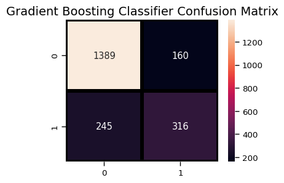

```python
plt.figure(figsize=(4,3))
sns.heatmap(confusion_matrix(y_test, gb_pred),
                annot=True,fmt = "d",linecolor="k",linewidths=3)

plt.title("Gradient Boosting Classifier Confusion Matrix",fontsize=14)
plt.show()
```

#### **Voting Classifier**

Let's now predict the final model based on the highest majority of voting and check it's score.

```python
from sklearn.ensemble import VotingClassifier
clf1 = GradientBoostingClassifier()
clf2 = LogisticRegression()
clf3 = AdaBoostClassifier()
eclf1 = VotingClassifier(estimators=[('gbc', clf1), ('lr', clf2), ('abc', clf3)], voting='soft')
eclf1.fit(X_train, y_train)
predictions = eclf1.predict(X_test)
print("Final Accuracy Score ")
print(accuracy_score(y_test, predictions))
```

```
Final Accuracy Score
0.8104265402843602
```

```python
print(classification_report(y_test, predictions))
```

```
              precision    recall  f1-score   support

           0       0.85      0.90      0.87      1549
           1       0.67      0.55      0.61       561

    accuracy                           0.81      2110
   macro avg       0.76      0.73      0.74      2110
weighted avg       0.80      0.81      0.80      2110
```

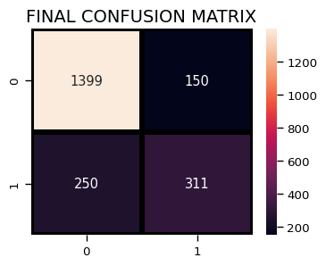

```python
plt.figure(figsize=(4,3))
sns.heatmap(confusion_matrix(y_test, predictions),
                annot=True,fmt = "d",linecolor="k",linewidths=3)

plt.title("FINAL CONFUSION MATRIX",fontsize=14)
plt.show()
```

Customer churn is definitely bad to a firm ’s profitability. Various strategies can be implemented to eliminate customer churn. The best way to avoid customer churn is for a company to truly know its customers. This includes identifying customers who are at risk of churning and working to improve their satisfaction. Improving customer service is, of course, at the top of the priority for tackling this issue. Building customer loyalty through relevant experiences and specialized service is another strategy to reduce customer churn. Some firms survey customers who have already churned to understand their reasons for leaving in order to adopt a proactive approach to avoiding future customer churn.